# Advanced Lane Finding Project

The goals / steps of this project are the following:

1. Compute the camera calibration matrix and distortion coefficients given a set of chessboard images.
2. Apply a distortion correction to raw images.
3. Apply a perspective transform to image ("birds-eye view").
4. Use color transforms, gradients, etc., to create a thresholded binary image.
5. Detect lane pixels and fit to find the lane boundary.
6. Determine the curvature of the lane and vehicle position with respect to center.
7. Warp the detected lane boundaries back onto the original image.
8. Output visual display of the lane boundaries and numerical estimation of lane curvature and vehicle position.
9. Pipeline section
10. Video Output

## To Check overall picture of the project you can directly check the pipeline section that explain everything

### 1. compute the camera calibration using chessboard images

Here i used all the 9X6 chessboard images to obtain objects and image points. Below is one image with detected corners

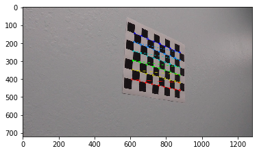

### 2. Applying a distortion correction on test2.jpg

#### undistort()

```
    function is used to undistort the distorted image
```

Here i used `cv2.calibrateCamera` function to find the camera matrix and distortion coefficients And used `cv2.undistort` to undistort the distored image

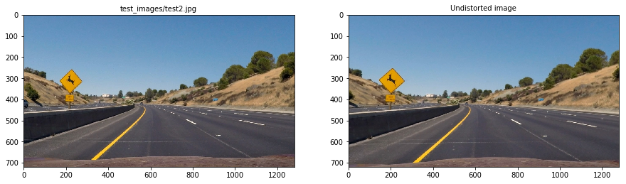

### 3. Apply a perspective transform to image ("birds-eye view").

I changed the strategy from this point. Previously i was first converting the raw image into a binary threshold image then taking the perspective transform. But after lot of experiment in color spaces and gradient method. I didn't get satifactory result. The main problem with farther lane pixels in the image which are not identified when there is dark in image or too far. So whenever we find binary threshold image result was not good. So i decided to first transform image in perspective view. Which gives all the lane pixel clearly in vertically distributed on the image. And after finding binary image result is also good.

Here i used below four source and destination points. This i found from straight line image (straight_lines1.jpg) given in test_images folder

```
imshape[0] = height of the image
imshape[1] = width of the image
```

Source points:

```
bottom_left = [0+130,imshape[0]]
bottom_right = [imshape[1]-80,imshape[0]]
top_left = [imshape[1]//2-85,imshape[0]//2+110]
top_right = [imshape[1]//2+95,imshape[0]//2+110]
```

Destination points:

```
bottom_left = [0+250,imshape[0]]
bottom_right = [imshape[1]-300,imshape[0]]
top_left = [0+250,0]
top_right = [imshape[1]-300,0]]
```

#### warp()

```
    function is used to change the perspective of the image
    Here i am using this warp() function to convert image to warp birds-eye view image
```

#### unwarp()

```
    function is used to apply the inverse perspective and convert it into original image
```

#### Applying perpective transform on test2.jpg

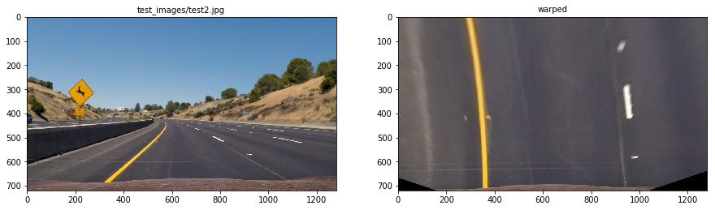

### 4. Use color transforms, gradients, etc., to create a thresholded binary image.

In this step i done a lot of experiment with different color spaces like RGB,HLS and gradients. After lot of experiment i decided to use S channel (threshold = (170,255)) from HLS color space. Which gives a good result in almost all the images together with sobelx gradient (threshold = (50,100)). It worked good until i got the issue in project_video. In one of the location where tree shadow appears this method failed. Then i again experimented with LUV,LAB color space.

```
I choose B channel from LAB color space with threshold (0,110). I found that this gives good result in all images even on dark one. But it works well on yellow lane only.

I also choose L channel from LUV color space with threshold (200,255). This worked for white lane.
```

So these two channel is sufficient to find the lane lines from all the images. Then i removed the S channel and sobelx gradient from my code.

#### binary_img()

```
    function is used to convert a image into a binary threshold image
```

#### Applying binary_img() function on test2.jpg

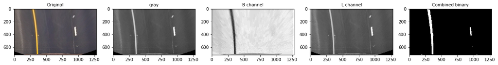

#### region_of_interest()

```
    function is used to apply a filtered mask on binary threshold image and return the image only with lane lines

    Here i choose the rectangular mask for the warp binary image.
```

#### Applying region_of_interest() function on test2.jpg

[figure not shown]

### 5. Detect lane pixels and fit to find the lane boundary.

#### find_lane_pixles()

```
    function is used to find the lane pixels on warped binary image
```

This function is used to find the left and right lane pixels on warped binary image Here i am identifying peaks in a histogram of the image to find the location of left and right lane. then identifying all non zero pixels around histogram peaks using the numpy function `numpy.nonzero()`. And using `numpy.polyfit()` function fitting a polynomial to each lane.

#### fit_polynomial()

```
    function is used to fit the polynomial after finding the lane pixels
```

#### Below function shows how the fit_polynomial() function is working

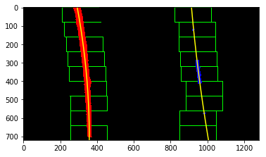

### 6. Determine the curvature of the lane and vehicle position with respect to center.

#### measure_curvature_real()

```
    function is used to find the left and right curvature of the lane in meter
```

Here i am calculating radious of curvature in metrs for left and right lane using the following code first i converted pixels into meters then using below code i calculated left and right curvature

```
ym_per_pix = 30/imshape[0]
xm_per_pix = 3.7/imshape[1]

ploty = np.linspace(0,imshape[0]-1,imshape[0])

left_fit = np.polyfit(lefty*ym_per_pix,leftx*xm_per_pix,2)
right_fit = np.polyfit(righty*ym_per_pix,rightx*xm_per_pix,2)

y_eval = np.max(ploty)

left_curvered = ((1 + (2*left_fit[0]*y_eval*ym_per_pix + left_fit[1])**2)**1.5)/ np.absolute(2*left_fit[0])
right_curvered = ((1 + (2*right_fit[0]*y_eval*ym_per_pix + right_fit[1])**2)**1.5)/np.absolute(2*right_fit[0])
```

#### cal_curvature_centeroffset()

```
    function is used to find the average curvature of the lane and vehicle position with repect to center
```

Here i am calculating the ratious of curvature and position of vehicle with respect to center offset for test2.jpg

```
Radius of curvature: 3833.19 m
Center offset: -0.12 m
```

### 7. Warp the detected lane boundaries back onto the original image.

#### unwarped_binary_img_with_lane()

```
    function is used to unwarp the image with detected lane into masked binary image
    After applying this function we will get the masked binary image with detected lane
```

### 8. Output visual display of the lane boundaries and numerical estimation of lane curvature and vehicle position.

#### draw_lane()

```
    function is used to display the lane boundaries which we got from unwarped_binary_img_with_lane() function on original image
```

#### put_text_on_image()

```
    function is used to display the lane curvature and vehicle position on original image
```

Here i am plotting the polynomials on to the warped image, fill the space between the polynomials to highlight the lane and then applying inverse perspective trasformation to unwarp the image from birds eye back to its original perspective. And printing the distance from center and radius of curvature on to the final image.

Below is the lane detected on test2.jpg

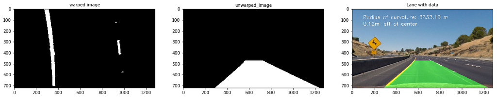

### 9. Pipeline section

#### pipeline()

```
    function takes the original image and gives the final image with detected lane line and details displayed on the image
    This function has display arugment which display overall pipeline output when the value of the argument is True
```

#### Applying pipeline() function on test2.jpg

#### images during the pipeline process gives the clear picture how the pipeline works

[figure not shown]

### 10. Video Output

#### process_image()

```
    function performs the same operation as pipeline() function does
    i am using this function to detect lane on project_video
```

#### Importing everything needed to edit/save/watch video clips

#### Applying process_image() function on project_video.mp4

[video not shown]

### Discussion

#### For Challenge project issues and improvements

```
1. Previously i started s channel together with sobelx gradient but that not worked in project video where dark shadow appeared. Then i used B channel from LAB color space and L channel from LUV color space. B channel identified yellow lane and L channel identified white lane. These two channel is sufficient to identified lane on the road.
2. Normal project pipeline is not working for challange and harder_challenge video.
3. The lanes lines in the challenge videos were extremely difficult to detect. They were either too bright or too dull.
4. For the harder challenge i will try to take perspective transform for smaller section. I tried this but then it failed for normal project video. There is one thing which i never tried yet. When no lane detected consider the previous frame. That may be solve my issue for both video.
5. The challenge video has a section where the car goes underneath a tunnel. Whole image is in black.
```